# Визуализация биомедицинских данных. Домашнее задание

# О задании

В этом задании почти соблюдаются принципы классицизма: одно задание — не меньше одного графика и не меньше одного чанка, если не сказано иное. Правило действует, даже когда задание просит вернуться к предыдущему графику. При этом вы всегда можете расширить интерпретацию или показать то же самое ещё и другим, более подходящим, на ваш взгляд, способом — дополнительными графиками к заданию. Некоторые пункты касаются того, о чём на занятиях прямо не говорили, и потребуют справки и документации; обычно такие места оговорены в условии явно.

Инструкция по сдаче задания указана в `README.md` и на Stepik

## **Общие требования к оформлению**

1. Старайтесь соблюдать единый стиль оформления и структуру отчёта, если в задании не указано иное. Не оставляйте в финальном отчёте лишние чанки кода, текст или комментарии, которые не относятся к решению задания.
2. Любой output должен быть читаемым и достаточно кратким, чтобы было удобно просматривать. Не оставляйте «полотна» текста или вывода. Объёмный output оформите аккуратно, либо сократите, либо вовсе уберите. Таблицы оформляйте c пмощью flextable, а для графиков подбирайте подходящий размер и пропорции
3. Ответы на вопросы оформляйте в виде текста явно, не в виде комментариев к коду.
4. Сохраняйте исходную структуру проекта в репозитории. Не добавляйте лишние файлы, которые не относятся к проекту или выполнению заданий.
5. Оформление коммитов и веток на GitHub должно соответствовать общим правилам для всех курсов Института биоинформатики (см. соответствующий материал на курсе Python).

# Правила и требования для всех задач *в этом домашней задании*

**Выполняйте их, даже если в тексте задания они не упомянуты.**

- Под каждым графиком напишите интерпретацию: что на нём видно и какой вывод из этого следует, в 2–4 предложениях. Перечисление геомов и цветов интерпретацией не считается. Если вывода нет или данных для него мало, так и напишите.
- Делайте текст на графике настолько крупным, насколько позволяют сам график и ваше чувство меры. Читаемые надписи — важный (но не так уж часто встречающийся) элемент графиков.
- Не используйте фон ggplot2 по умолчанию.
- У каждого графика должен быть заголовок, отражающий его суть, и правильно названные оси.
- Все подписи на графиках — на русском языке.
- Старайтесь, чтобы графики были достаточно крупными и читались не только в отрендеренном HTML, но и при интерактивном запуске чанков в Positron.
- Однотипные графики стройте функцией конспект 2, раздел «П6 · Функция для однотипных графиков (слайд П6)»).

# Цвета факультетов — как в конспектах: Гриффиндор `#B32025`, Хаффлпафф `#D7A900`, Рейвенкло `#2E5EAA`, Слизерин `#2F7D4A`. В задании 10 цвета берите с образца.

## П6 · Функция для однотипных графиков (слайд П6)

histogram_for <- function(data, variable, bins = 30) {

ggplot(data, aes(x = {{ variable }})) + geom_histogram(bins = bins) + labs(y = “Студентов”)

}

histogram_for(hogwarts, result, bins = 20)

# `{ }` передаёт имя столбца в функцию, `map()` строит график для каждого значения, patchwork собирает их на одну страницу:

Для некоторых заданий понадобится пакет patchwork: он собирает несколько графиков в один (конспект 2, раздел «П9 · Несколько графиков на одну страницу (слайд П9)»). Советуем почитать его документацию и пользоваться им в домашней работе. Для задания 8 нужен пакет gghighlight. Если каких-то пакетов нет, установите их один раз в консоли: `install.packages(c("patchwork", "gghighlight"))`.

## П9 · Несколько графиков на одну страницу (слайд П9)

patchwork::wrap_plots(p_hist, p_box, ncol = 2) + patchwork::plot_annotation(tag_levels = “A”)

[output not shown]

```r
hogwarts <- read_csv("data/hogwarts_2026.csv", show_col_types = FALSE)
```

# Задание 1

Постройте барплот (столбчатую диаграмму), отражающий распределение числа студентов по курсам обучения. Раскрасьте столбики любым понравившимся цветом: подойдёт и название цвета, и hex-код. Задайте и цвет контура столбиков. Проинтерпретируйте график.

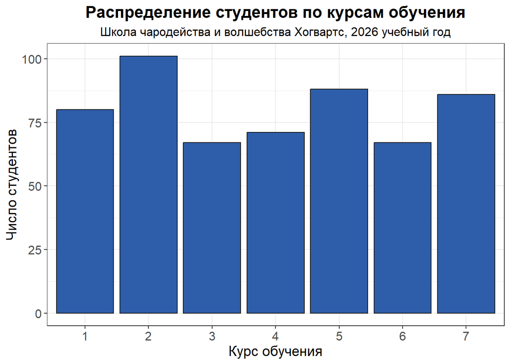

```r
ggplot(hogwarts, aes(x = course)) +
  geom_bar(fill = "#2E5EAA", colour = "#1A1A1A") +
  labs(
    title    = "Распределение студентов по курсам обучения",
    subtitle = "Школа чародейства и волшебства Хогвартс, 2026 учебный год",
    x        = "Курс обучения",
    y        = "Число студентов"
  ) +
  scale_x_discrete(limits = as.character(1:7)) +
  theme_bw() +
  theme(
    text            = element_text(size = 14),
    plot.title      = element_text(size = 16, face = "bold", hjust = 0.5),
    plot.subtitle   = element_text(size = 12, hjust = 0.5),
    axis.title      = element_text(size = 14),
    axis.text       = element_text(size = 12),
    legend.position = "none"
  )
```

# Задание 2

Постройте новый барплот, отражающий распределение числа студентов по факультетам. Добавьте на график вторую факторную переменную — происхождение (`bloodStatus`).

С помощью аргумента `position` измените график так, чтобы каждый столбец показывал распределение факультета по чистоте крови в долях. Запишите текстом в этом файле, какой вывод можно сделать из графика.

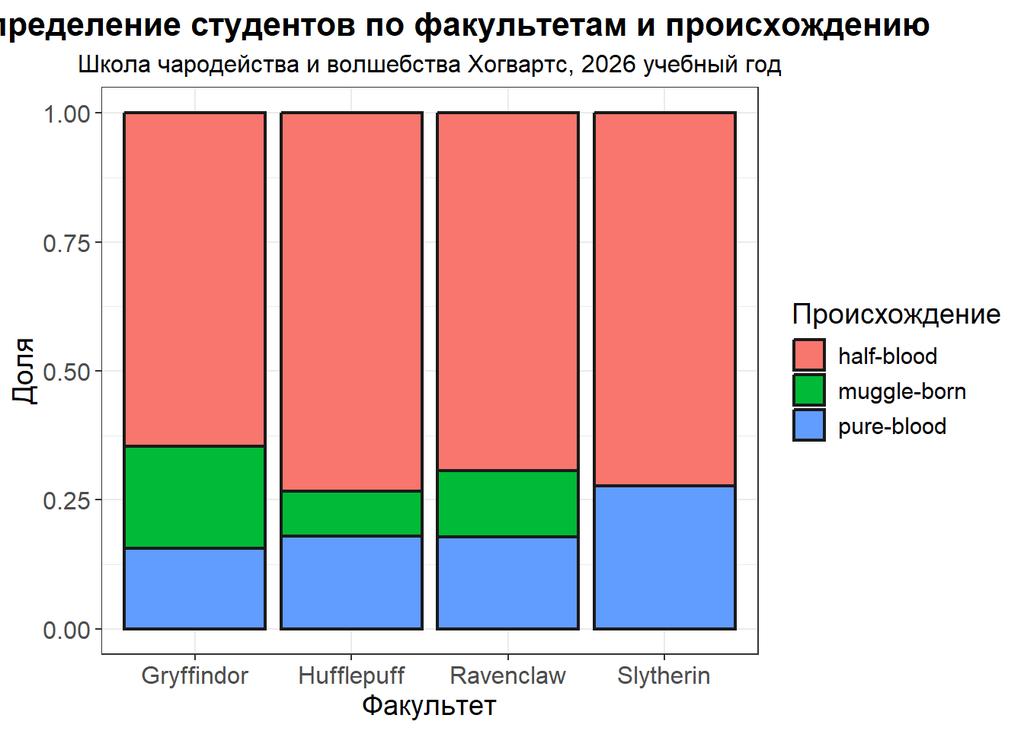

```r
ggplot(hogwarts, aes(x = house, fill = bloodStatus)) +
  geom_bar(position = "fill", colour = "#1A1A1A", linewidth = 0.8) +
  labs(
    title    = "Распределение студентов по факультетам и происхождению",
    subtitle = "Школа чародейства и волшебства Хогвартс, 2026 учебный год",
    x        = "Факультет",
    y        = "Доля",
    fill     = "Происхождение"
  ) +
  theme_bw() +
  theme(
    text            = element_text(size = 14),
    plot.title      = element_text(size = 16, face = "bold", hjust = 0.5),
    plot.subtitle   = element_text(size = 12, hjust = 0.5),
    axis.title      = element_text(size = 14),
    axis.text       = element_text(size = 12)
  )
```

# Задание 3

Отобразите распределение баллов, заработанных студентами на 3-й неделе обучения, по факультетам. Постарайтесь показать одновременно и форму распределения, и некоторые описательные статистики. Отсортируйте факультеты в порядке убывания медианного балла за 3-ю неделю (функция, которую мы разбирали на слайде 21, по умолчанию сортирует именно по медиане, так что задавать медиану отдельным аргументом не нужно). Если используете `geom_jitter()`, постарайтесь, чтобы точки лежали кучнее вдоль оси, которая не отражает само распределение. Проинтерпретируйте график.

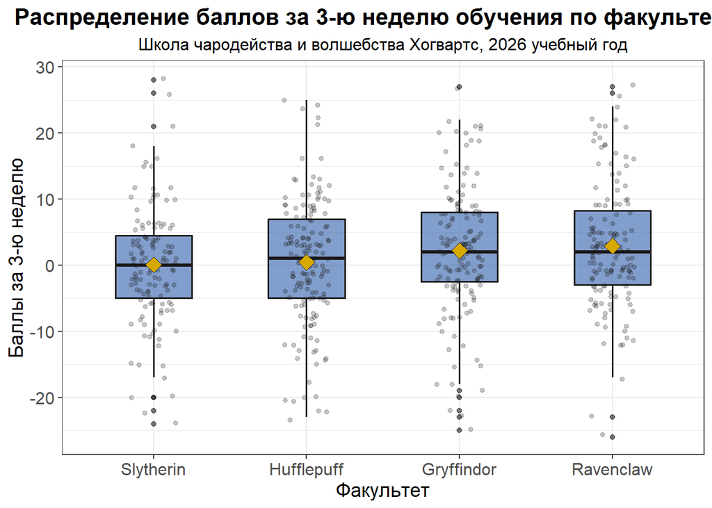

```r
ggplot(hogwarts, aes(x = fct_reorder(house, week_3), y = week_3)) +
  geom_boxplot(fill = "#2E5EAA", alpha = 0.6, width = 0.5,
               color = "#1A1A1A", linewidth = 0.6) +
  geom_jitter(width = 0.15, alpha = 0.25, color = "#1A1A1A", size = 1.2) +
  stat_summary(fun = mean, geom = "point", shape = 23,
               size = 4, fill = "#D7A900", color = "#1A1A1A") +
  labs(
    title    = "Распределение баллов за 3-ю неделю обучения по факультетам",
    subtitle = "Школа чародейства и волшебства Хогвартс, 2026 учебный год",
    x        = "Факультет",
    y        = "Баллы за 3-ю неделю"
  ) +
  theme_bw() +
  theme(
    text            = element_text(size = 14),
    plot.title      = element_text(size = 16, face = "bold", hjust = 0.5),
    plot.subtitle   = element_text(size = 12, hjust = 0.5),
    axis.title      = element_text(size = 14),
    axis.text       = element_text(size = 12)
  )
```

**Интерпретация:** На всех факультетах кроме Пуффендуя ромб (среднее) находится чуть выше медианной линии, то есть распределения слегка скошены вправо — есть небольшое количество студентов с высокими баллами, которые повышают среднее. Гриффендор и Когтевран показывают лучшие результаты, остальные факультеты отстают. При этом разброс баллов внутри каждого факультета очень велик, а усы и выбросы простираются от −25 до +28, что говорит о высокой неоднородности успеваемости студентов внутри факультетов.

# Задание 4

Постройте гистограмму результатов любого экзамена на ваш выбор, кроме зельеварения. Настройте оптимальное, на ваш взгляд, число столбцов гистограммы. Выполните фасетирование по курсу. Постарайтесь, чтобы график был по возможности компактным. Проинтерпретируйте график.

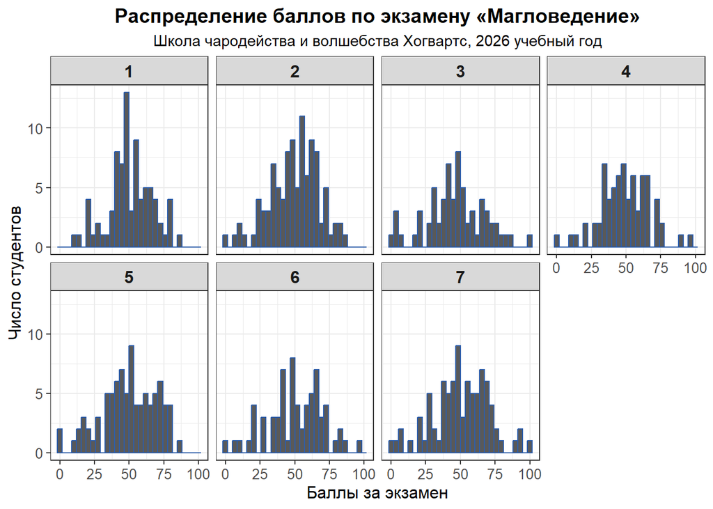

```r
ggplot(hogwarts, aes(x = `Muggle studies exam`)) +
  geom_histogram(bins = 30, colour = "#2E5EAA")+
  facet_wrap(~ course, nrow = 2) +
  labs(
    title    = "Распределение баллов по экзамену «Магловедение»",
    subtitle = "Школа чародейства и волшебства Хогвартс, 2026 учебный год",
    x        = "Баллы за экзамен",
    y        = "Число студентов"
  ) +
    theme_bw() +
  theme(
    text            = element_text(size = 12),
    plot.title      = element_text(size = 14, face = "bold", hjust = 0.5),
    plot.subtitle   = element_text(size = 11, hjust = 0.5),
    strip.text      = element_text(size = 12, face = "bold"),
    axis.title      = element_text(size = 12),
    axis.text       = element_text(size = 10)
  )
```

# Задание 5

Постройте скаттерплот, показывающий связь между суммарным баллом студента за год и оценкой за экзамен (по травологии, магловедению, нумерологии и зельеварению). Добавьте на график линию тренда. Удалите доверительную область и сделайте линию прямой. Подумайте, как обойтись без того, чтобы записывать одни и те же координаты x и y дважды. Проинтерпретируйте график.

Раскрасьте точки в разные цвета в соответствии с факультетами. Проинтерпретируйте полученный результат.

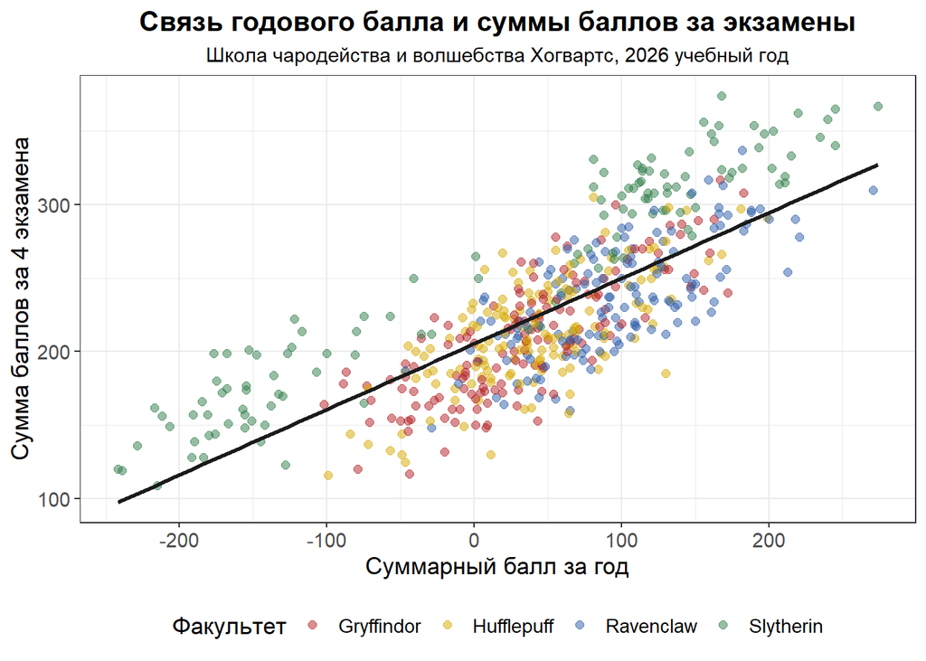

```r
hogwarts <- hogwarts |>
  mutate(
    total_exam = `Muggle studies exam` + `Herbology exam` +
                 `Potions exam` + `Arithmancy exam`
  )

ggplot(hogwarts, aes(x = result, y = total_exam)) +
  geom_point(aes(color = house), alpha = 0.5, size = 2) +
  geom_smooth(method = "lm", se = FALSE, color = "#1A1A1A", linewidth = 1) +
  scale_color_manual(
    name = "Факультет",
    values = c("Gryffindor" = "#B32025", "Hufflepuff" = "#D7A900",
               "Ravenclaw" = "#2E5EAA", "Slytherin" = "#2F7D4A")
  ) +
  labs(
    title    = "Связь годового балла и суммы баллов за экзамены",
    subtitle = "Школа чародейства и волшебства Хогвартс, 2026 учебный год",
    x        = "Суммарный балл за год",
    y        = "Сумма баллов за 4 экзамена"
  ) +
  theme_bw() +
  theme(
    text            = element_text(size = 13),
    plot.title      = element_text(size = 15, face = "bold", hjust = 0.5),
    plot.subtitle   = element_text(size = 11, hjust = 0.5),
    axis.title      = element_text(size = 13),
    axis.text       = element_text(size = 11),
    legend.position = "bottom"
  )
```

**Интерпретация:** На графике чётко видна положительная линейная связь между суммарным баллом студента за год и суммой баллов за четыре экзамена: чем выше результаты на экзаменах, тем лучше годовой балл. Это ожидаемо, поскольку экзаменационные оценки, вероятно, составляют значимую часть итогового годового балла. Cтуденты Слизерина в основном сконцентрированы в правой верхней части графика - у них высокие баллы как за год, так и за экзамены, скорее всего из-за высоких баллов по Зельеварению, но есть и часть студентов Слизерина имеет отрицатеьный годовой балл - знч ни где-то его теряют из-за посещаемости или из-за неудач на другух предматах. Студенты Гриффиндора и Пуффендуя чаще находятся в левой нижней части - их результаты скромнее.

# Задание 6

Сравните распределение баллов за экзамен по прорицанию и за экзамен по защите от тёмных искусств. Сделайте это тремя разными способами. Под разными способами понимаются идеологически разные геомы или способы группировки. Не считаются разными способами изменения константных визуальных параметров (цвет заливки, размер фигур, другие чисто стилевые отличия) на сходных в остальном графиках.

Объедините графики так, чтобы итоговый график имел два столбца и две строки. Два графика должны стоять в верхней строке и занимать равную площадь. Третий график должен занимать нижнюю строку целиком. Проинтерпретируйте график.

```r
p1 <- hogwarts |>
  pivot_longer(cols = c(`Divinations exam`, `Defence against the dark arts exam`),
               names_to = "exam", values_to = "score") |>
  ggplot(aes(x = exam, y = score, fill = exam)) +
  geom_boxplot()+
  scale_x_discrete(labels = c("Прорицание", "Защита от темных искусств")) +
  labs(title = "Сравнение баллов за экзамены", x = "Экзамен", y = "Баллы") +
  theme_bw() +
  theme(legend.position = "none", plot.title = element_text(hjust = 0.5),text = element_text(size = 12))
```

```r
p2 <- hogwarts |>
  pivot_longer(cols = c(`Divinations exam`, `Defence against the dark arts exam`),
               names_to = "exam", values_to = "score") |>
  ggplot(aes(x = exam, y = score, fill = exam)) +
  geom_violin(trim = FALSE, alpha = 0.7, color = "#1A1A1A") +
  scale_fill_manual(values = c("Divinations exam" = "#2E5EAA",
                               "Defence against the dark arts exam" = "#2F7D4A"),
                    labels = c(labels = c("Прорицание", "Защита от тёмных искусств")),
                    name = "Экзамен") +
  labs(title = "Сравнение баллов за экзамены", x = "Экзамен", y = "Баллы") +
  theme_bw() +
  theme(legend.position = "none", plot.title = element_text(hjust = 0.5))
```

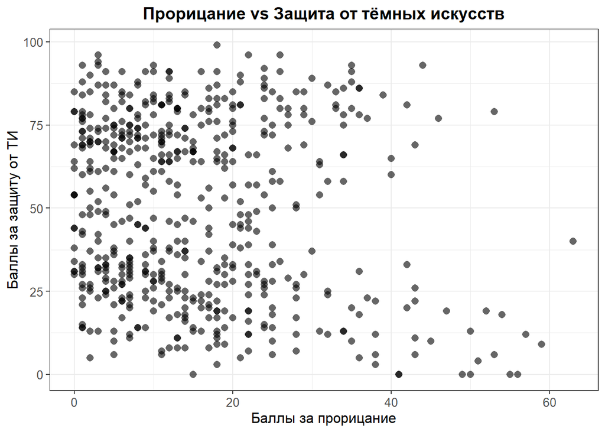

```r
p3 <- ggplot(hogwarts, aes(x = `Divinations exam`, y = `Defence against the dark arts exam`)) +
  geom_point(alpha = 0.6, size = 2.5, shape = 16) +
  labs(title = "Прорицание vs Защита от тёмных искусств",
       x = "Баллы за прорицание",
       y = "Баллы за защиту от ТИ") +
  theme_bw() +
  theme(plot.title = element_text(size = 14, face = "bold", hjust = 0.5),
        axis.title = element_text(size = 12),
        axis.text = element_text(size = 10))
p3
```

[figure not shown]

```r
print(wrap_plots(p1, p2, p3, design = "12\n33"))
```

# Задание 7

Постройте диаграмму рассеяния (скаттерплот), где по осям отложены результаты экзаменов по заклинаниям и по древним рунам. На графике есть некоторая проблема. Если вам трудно её определить, возьмите подсказку: постройте скаттерплот по данным из файла `data/podskazka.csv`. По оси x отложите переменную `y`, по оси y — переменную `x`, а пределы оси y задайте от 200 до 500. Предложите и подкрепите визуализациями не менее трёх способов решить эту проблему.

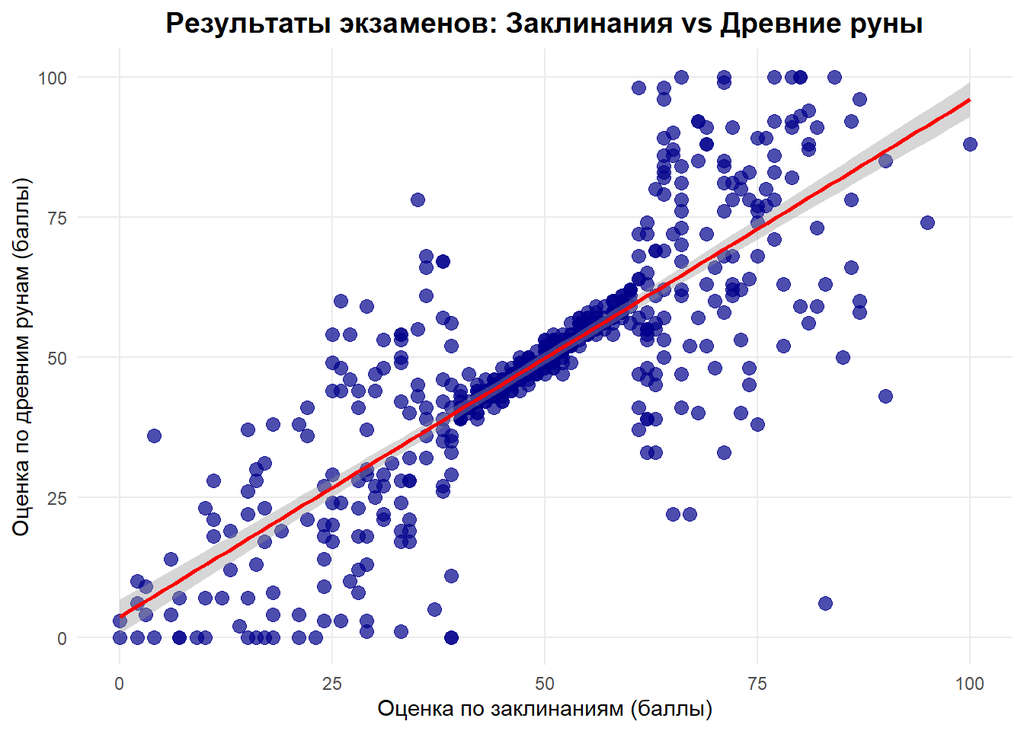

```r
ggplot(hogwarts, aes(x = `Charms exam`, y = `Study of ancient runes exam`)) +
  geom_point(color = "darkblue", size = 3, alpha = 0.7) +
  geom_smooth(method = "lm", color = "red", se = TRUE) +
  labs(
    title = "Результаты экзаменов: Заклинания vs Древние руны",
    x = "Оценка по заклинаниям (баллы)",
    y = "Оценка по древним рунам (баллы)"
  ) +
  theme_minimal() +
  theme(
    plot.title = element_text(hjust = 0.5, size = 14, face = "bold"),
    panel.grid.minor = element_blank()
  )
```

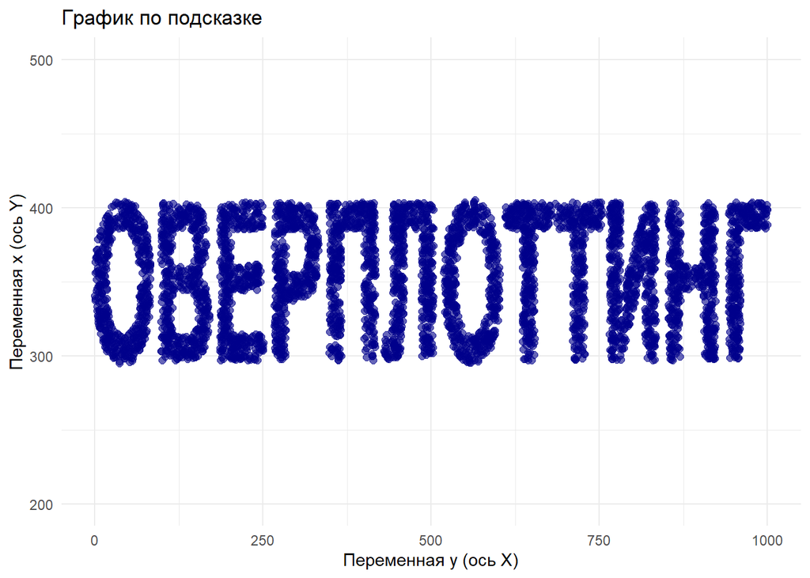

```r
podskazka <- read.csv("data/podskazka.csv")
ggplot(podskazka, aes(x=y,y=x))+
  geom_point(color = "darkblue", size = 2, alpha = 0.6) +
  ylim(200, 500) +
  labs(
    title = "График по подсказке",
    x = "Переменная y (ось X)",
    y = "Переменная x (ось Y)"
  ) +
  theme_minimal()
```

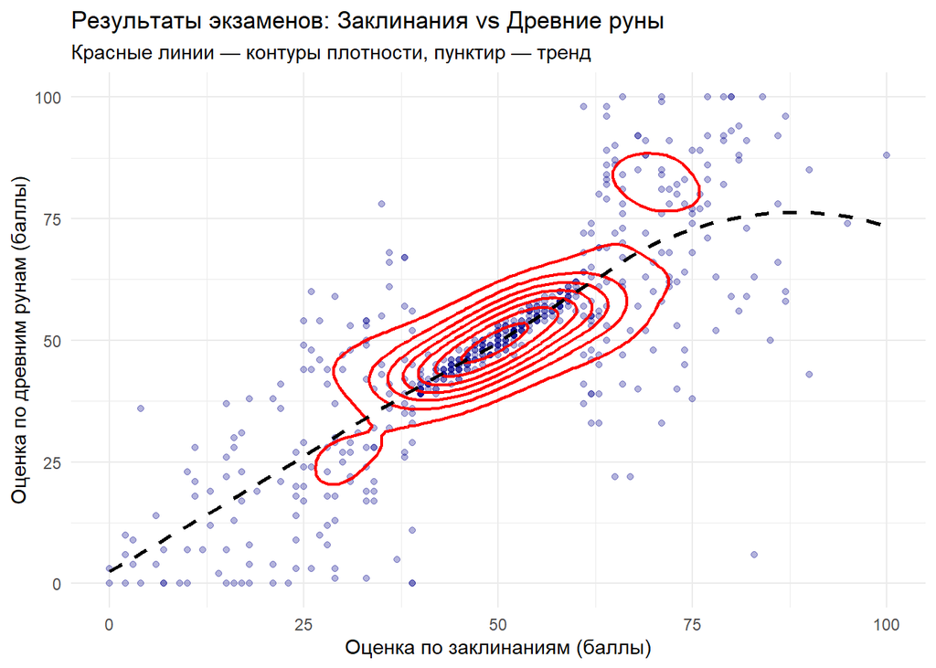

```r
ggplot(hogwarts, aes(x = `Charms exam`, y = `Study of ancient runes exam`)) +
  geom_point(color = "darkblue", size = 1.5, alpha = 0.3) +
  geom_density_2d(color = "red", linewidth = 0.8) +
  geom_smooth(method = "loess", color = "black", se = FALSE, linetype = "dashed") +
  labs(
    title = "Результаты экзаменов: Заклинания vs Древние руны",
    subtitle = "Красные линии — контуры плотности, пунктир — тренд",
    x = "Оценка по заклинаниям (баллы)",
    y = "Оценка по древним рунам (баллы)"
  ) +
  theme_minimal()
```

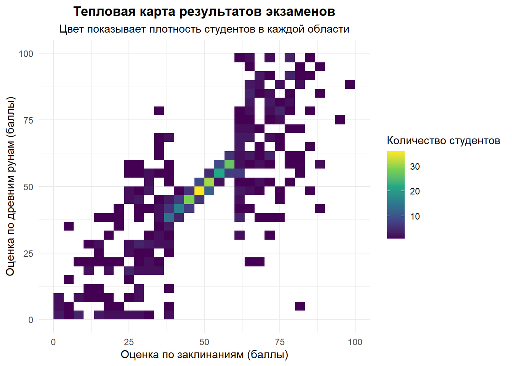

```r
ggplot(hogwarts, aes(x = `Charms exam`, y = `Study of ancient runes exam`)) +
  geom_bin2d(bins = 30) +
  scale_fill_viridis_c(name = "Количество студентов", option = "D") +
  labs(
    title = "Тепловая карта результатов экзаменов",
    subtitle = "Цвет показывает плотность студентов в каждой области",
    x = "Оценка по заклинаниям (баллы)",
    y = "Оценка по древним рунам (баллы)"
  ) +
  theme_minimal() +
  theme(
    plot.title = element_text(hjust = 0.5, face = "bold"),
    plot.subtitle = element_text(hjust = 0.5)
  )
```

```r
library(hexbin)
```

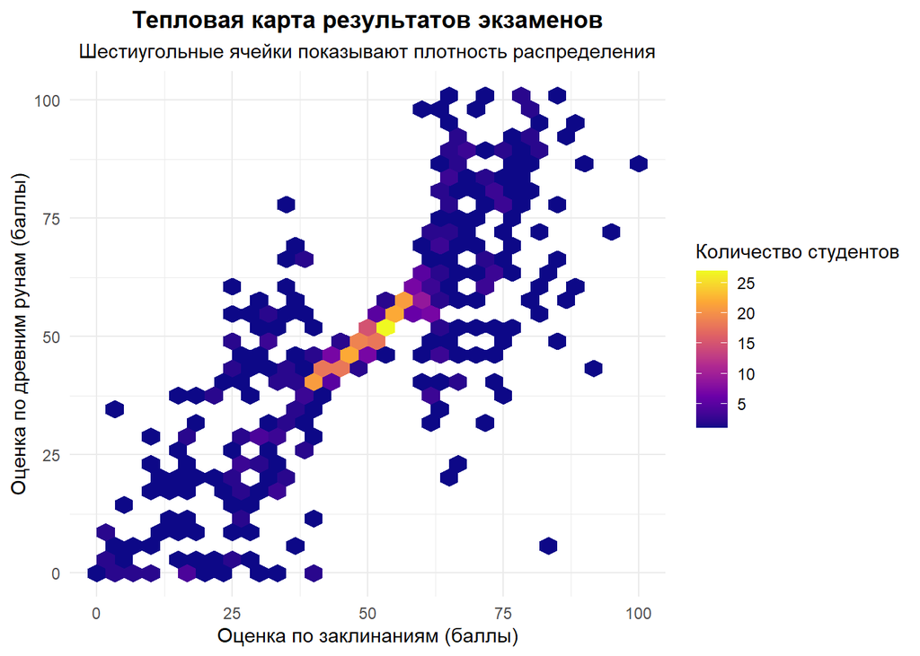

```r
ggplot(hogwarts, aes(x = `Charms exam`, y = `Study of ancient runes exam`)) +
  geom_hex(bins = 30) +
  scale_fill_viridis_c(name = "Количество студентов", option = "C") +
  labs(
    title = "Тепловая карта результатов экзаменов",
    subtitle = "Шестиугольные ячейки показывают плотность распределения",
    x = "Оценка по заклинаниям (баллы)",
    y = "Оценка по древним рунам (баллы)"
  ) +
  theme_minimal() +
  theme(
    plot.title = element_text(hjust = 0.5, face = "bold"),
    plot.subtitle = element_text(hjust = 0.5)
  )
```

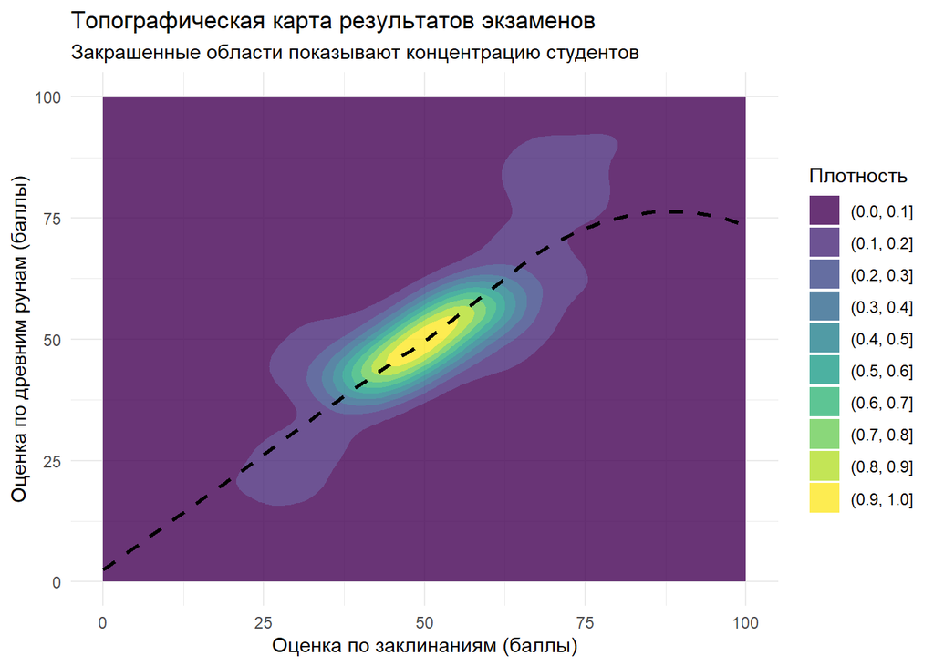

```r
ggplot(hogwarts, aes(x = `Charms exam`, y = `Study of ancient runes exam`)) +
  geom_density_2d_filled(contour_var = "ndensity", alpha = 0.8) +
  scale_fill_viridis_d(name = "Плотность") +
  geom_smooth(method = "loess", color = "black", se = FALSE, linewidth = 1, linetype = "dashed") +
  labs(
    title = "Топографическая карта результатов экзаменов",
    subtitle = "Закрашенные области показывают концентрацию студентов",
    x = "Оценка по заклинаниям (баллы)",
    y = "Оценка по древним рунам (баллы)"
  ) +
  theme_minimal()
```

**Проблема и способы её решения:** В середине графика сконцентрировано слишком много точек, также точки справа и слева от скопления точек в середине тянутся вверх и вниз одинаково равномерно. Благодаря недвусмысленной подсказке, проблема в оверплотинге - это проблема визуализации данных, которая возникает, когда на графике (чаще всего на диаграмме рассеяния / scatterplot) наносится слишком много точек, и они начинают перекрывать друг друга. В нашем задании с экзаменами Хогвартса оверплоттинг возник именно из-за того, что оценки — это целые числа, и много студентов набрали одинаковые баллы. Решаем: 1.Сделала точки полупрозрачными и маленькими. Там, где точки наслаиваются друг на друга, цвет станет темнее/насыщеннее, и вы увидите «ядро» скопления. Нарисовала контуры плотности, чтобы показать где сосредоточена основная масса студентов. 2.Построила тепловую карту с прямоугольными и шестиугольными ячейками. Плоскость графика разбивается на сетку (в моём случае 30×30 ячеек), и каждая ячейка окрашивается в цвет в зависимости от количества попавших в неё точек. Теперь видно «горячую зону» - диагональную полосу с высокой концентрацией студентов (около 50–60 баллов по обоим предметам), а также «холодные» разреженные области по краям. 3.Построила топографическую карту с помощью закрашенных контуров плотности. В отличие от обычных линий, этот метод закрашивает области между изолиниями разными цветами из палитры что позволяет визуализировать плотность распределения в виде плавных градиентов, напоминающих карту высот. На графике видны концентрации студентов (самые яркие цвета в центре диагонали) и плавное снижение плотности к периферии. Дополнительно есть сглаженная линия тренда, чтобы подчеркнуть нелинейный характер связи между оценками.

# Задание 8

Используйте таблицу с баллами по неделям для первых 30 студентов, которую мы получили на занятии (`first_30`, конспект 2, раздел «Линии: `group`, спагетти, акцент, профиль (слайд 53)»). В ней пока нет столбца `bloodStatus`, а он понадобится для подписей. Постройте лайнплоты для всех студентов. Выделите при помощи пакета gghighlight студентов факультета Рейвенкло, на лейблах отразите их происхождение.

Линии студентов других факультетов покрасьте в нейтральный серый цвет и задайте его явно, а их толщину сделайте не больше трети стандартной. Проинтерпретируйте график.

```r
install.packages("gghighlight")
library(gghighlight)
```

```r
library(ggrepel)
```

```r
weeks_long <- hogwarts |>
  select(id, house, bloodStatus, starts_with("week_")) |>
  pivot_longer(
    cols = starts_with("week_"),
    names_to = "week",
    values_to = "points"
  ) |>
  mutate(week = parse_number(week))

first_30 <- weeks_long |> filter(id <= 30)
student_30 <- weeks_long |> filter(id == 30)

weeks_long
```

```
# A tibble: 22,400 × 5
      id house     bloodStatus  week points
   <dbl> <chr>     <chr>       <dbl>  <dbl>
 1     1 Slytherin half-blood      1      0
 2     1 Slytherin half-blood      2     -5
 3     1 Slytherin half-blood      3      0
 4     1 Slytherin half-blood      4      9
 5     1 Slytherin half-blood      5      4
 6     1 Slytherin half-blood      6    -17
 7     1 Slytherin half-blood      7      9
 8     1 Slytherin half-blood      8      7
 9     1 Slytherin half-blood      9     -5
10     1 Slytherin half-blood     10     15
# ℹ 22,390 more rows
```

```r
summary(first_30$points)
```

```
   Min. 1st Qu.  Median    Mean 3rd Qu.    Max.
-50.000  -4.000   1.000   1.228   7.000  50.000
```

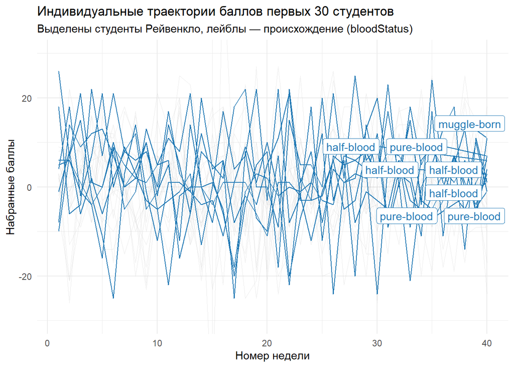

```r
ggplot(first_30, aes(x = week, y = points, group = id, colour = house)) +
  geom_line() +
  gghighlight(
    house == "Ravenclaw",
    label_key = bloodStatus,  # ← gghighlight сам подпишет линии происхождением
    unhighlighted_params = list(colour = "gray80", linewidth = 0.3, alpha = 0.4)
  ) +
  coord_cartesian(ylim = c(-30, 30)) +
  scale_colour_manual(values = c("Ravenclaw" = "#1f78b4",
                                  "Gryffindor" = "gray80",
                                  "Slytherin" = "gray80",
                                  "Hufflepuff" = "gray80")) +
  labs(title = "Индивидуальные траектории баллов первых 30 студентов",
       subtitle = "Выделены студенты Рейвенкло, лейблы — происхождение (bloodStatus)",
       x = "Номер недели", y = "Набранные баллы") +
  theme_minimal() +
  theme(legend.position = "none")
```

**Интерпретация:** На графике представлены индивидуальные траектории баллов первых 30 студентов Хогвартса в течение 40 недель. График чрезвучайно сложно интерпретирвоать из-за наложения линий. Линии студентов факультета Рейвенкло выделены синим цветом, студенты остальных факультетов показаны тонкими серыми линиями для создания контекста. Четких трендов нет, высокая вариабельность данных. Линии студентов Когтевран не выделяются ни по уровню, ни по амплитуде колебаний от остальных факультетов. Принадлежность к Когтеврану не связана с более высокой или предсказуемой успеваемостью в этой выборке. Статус крови не влияет на динамику баллов.

# Задание 9

Подробно (останавливаясь на каждом пункте, а не в общем) опишите, какие стороны графика и интерпретации (она приводится ниже) вы считаете верными и сделанными в соответствии с хорошими практиками, а какие — нет. Сделайте свой график, который отвечает на тот же исследовательский вопрос, но лишён технических и интерпретационных недостатков оригинала (если вы таковые нашли и упомянули).

График лежит в файле `images/task_2_4.png`:

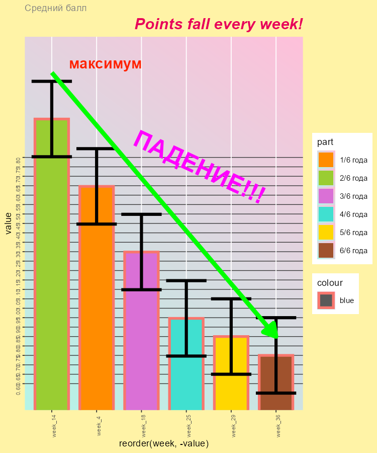

График к заданию 9

Интерпретация графика:

> В ходе исследования, проведенного в ФГБОУССО «Хогвартс» (далее Хогвартс) для оценки успешности образовательного процесса и психоэмоционального состояния участников вышеназванного процесса, были выявлены тревожные закономерности. А именно — при оценке среднего балла, полученного в течение недели совокупностью учащихся Хогвартса, была выявлена тенденция к резкому снижению данного показателя с течением времени. Так, в начале учебного процесса студенты набирали в среднем 2 балла (максимальный показатель). В последующие недели балл достоверно снижался, достигая минимальных значений к концу года (см. рис. 1). Мы полагаем, что данный процесс связан с ухудшением психологического состояния преподавателей означенного учебного заведения. Таким образом, в течение года они от мотивирующих мер положительного характера (добавление баллов за правильные ответы на занятиях и успехи во внеучебной деятельности) переходят к репрессивным действиям (учащающийся и увеличивающийся по модулю отъем баллов факультета за предполагаемые нарушения дисциплины, недостаточную, по мнению преподавателя, подготовку к занятию и пр.). Это вызывает снижение у учащихся мотивации к получению знаний, что вызывает следующий шаг снижения средненедельного балла — т.о., поведение педагогов вызывает своего рода circulus vitiosus.

> По итогам исследования и с учетом полученных результатов предлагается следующее: произвести замену профессорско-преподавательского состава с заменой педагогов, наиболее подверженных выгоранию в течение года (проявляющемуся в виде систематического снижения баллов студентам). Издать декрет о недопущении избыточного штрафования учащихся, начиная с 18-й недели учебного процесса до конца года. К нарушителям применять взыскания материально-магического характера. Объявить выговор с занесением в личное дело текущим представителям руководящего состава Хогвартса (далее дирекция).

```r
library(dplyr)
library(tidyr)
```

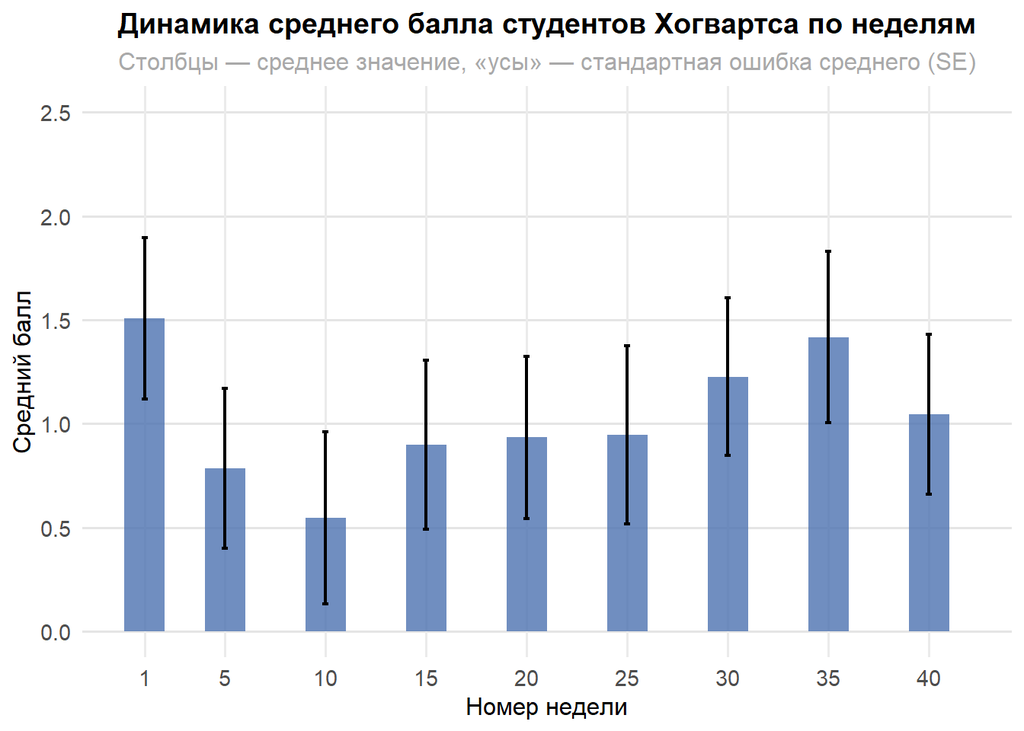

```r
#Выбор нужных колонок
data_step1 <- select(hogwarts,
                     id, house,
                     week_1, week_5, week_10, week_15, week_20, week_25, week_30, week_35, week_40)

# Перевод в длинный формат
data_step2 <- pivot_longer(data_step1,
                           cols = starts_with("week_"),
                           names_to = "week",
                           values_to = "points")

data_step3 <- mutate(data_step2,
                     week = readr::parse_number(week))

data_step4 <- group_by(data_step3, week) |>
  summarise(
    mean_points = mean(points, na.rm = TRUE),
    sd_points = sd(points, na.rm = TRUE),
    n = n(),
    .groups = "drop"
  )

data_step5 <- mutate(data_step4,
                     se = sd_points / sqrt(n))

data_step5 <- mutate(data_step5,
                     mean_points = if_else(is.na(mean_points), 0, mean_points),
                     se = if_else(is.na(se), 0, se))

ggplot(data = data_step5, aes(x = week, y = mean_points)) +
  geom_col(fill = "#4C72B0", alpha = 0.8, width = 2) +
  geom_errorbar(
    aes(ymin = mean_points - se,
        ymax = mean_points + se),
    width = 0.3,
    linewidth = 0.8,
    color = "black",
    na.rm = TRUE
  ) +
  scale_x_continuous(
    breaks = c(1, 5, 10, 15, 20, 25, 30, 35, 40),
    limits = c(0, 42)
  ) +
  scale_y_continuous(
    limits = c(0, 2.5),
    breaks = seq(0, 2.5, by = 0.5)
  ) +
  labs(
    title = "Динамика среднего балла студентов Хогвартса по неделям",
    subtitle = "Столбцы — среднее значение, «усы» — стандартная ошибка среднего (SE)",
    x = "Номер недели",
    y = "Средний балл"
  ) +
  theme_minimal(base_size = 12) +
  theme(
    plot.title = element_text(face = "bold", hjust = 0.5),
    plot.subtitle = element_text(hjust = 0.5, color = "darkgray"),
    panel.grid.minor = element_blank(),
    panel.grid.major.y = element_line(color = "gray90"),
    axis.text = element_text(size = 11),
    axis.title = element_text(size = 12)
  )
```

Воспроизведите график максимально близко к оригиналу и проинтерпретируйте его. Постарайтесь максимально точно отразить каждый элемент.

Образец лежит в файле `images/task_10.png`:

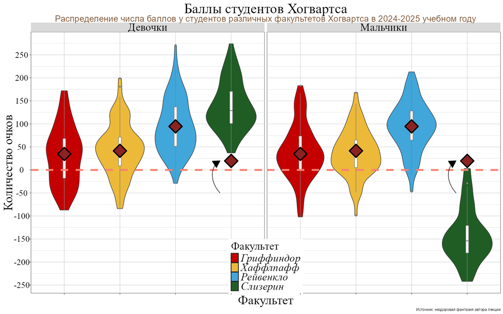

Образец к заданию 10

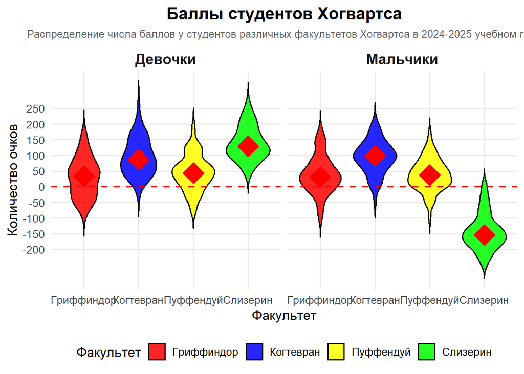

```r
data_plot <- hogwarts %>%
  select(sex, house, result) %>%
  mutate(
    house_ru = factor(
      recode(house,
             "Gryffindor" = "Гриффиндор",
             "Ravenclaw" = "Когтевран",
             "Hufflepuff" = "Пуффендуй",
             "Slytherin" = "Слизерин"),
      levels = c("Гриффиндор", "Когтевран", "Пуффендуй", "Слизерин"),
    ),
    sex_ru = recode(sex, "female" = "Девочки", "male" = "Мальчики")
  )

ggplot(data_plot, aes(x = house_ru, y = result, fill = house_ru)) +
  geom_violin(trim = FALSE, color = "black", alpha = 0.85, width = 0.8) +
  scale_fill_manual(
    name = "Факультет",
    values = c(
      "Гриффиндор" = "red",
      "Когтевран"  = "blue",
      "Пуффендуй"  = "yellow",
      "Слизерин"   = "green"
    )
  ) +
  stat_summary(fun = median, geom = "point", size = 6, shape = 23,
               color = "red", fill = "red", stroke = 1.5) +
  geom_hline(yintercept = 0, linetype = "dashed", color = "red", linewidth = 0.8) +
  facet_wrap(~sex_ru, nrow = 1) +
  scale_y_continuous(breaks = seq(-200, 250, by = 50)) +
  labs(
    title    = "Баллы студентов Хогвартса",
    subtitle = "Распределение числа баллов у студентов различных факультетов Хогвартса в 2024-2025 учебном году",
    x        = "Факультет",
    y        = "Количество очков"
  ) +
  theme_minimal(base_size = 13) +
  theme(
    plot.title    = element_text(hjust = 0.5, face = "bold", size = 16),
    plot.subtitle = element_text(hjust = 0.5, size = 10, color = "gray40"),
    strip.text    = element_text(size = 14, face = "bold"),
    panel.grid.minor = element_blank(),
    legend.position  = "bottom",
    legend.justification = "center",
    legend.box.just      = "center"
  )
```